# Statistical Computing Midterm Project

Pin-wei, Yu

5/1/2020

# Problem 1. Dirichlet Distribution

A Dirichlet Distribution is a continuous distribution on
$$A=\lbrace x = (x_1,x_2,...,x_d):x_i \geq 0 , \sum_{i=1}^{d}x_i = 1\rbrace$$
with pdf
$$f(x) =\frac{\Gamma(\sum_{j=1}^{d}\alpha_j)}{\prod_{j=1}^{d}\Gamma(\alpha_j)}x_1^{\alpha_1-1}x_2^{\alpha_2-1}...x_d^{\alpha_d-1}$$
We want to sample from this distribution.

### 1(a)Algorithm of Acceptance-Rejection Method

Step1: Set $C = max_x \lbrace \frac{f(x)}{g(x)} \rbrace$

Step2: Generate $U_1～Unif(0,1)$

Step3: Generate $X_2～g(x)=g_X$

Step4: Set $X_1=X_2$ if $U_1 \leq \frac{f(x_2)}{Cg(x_2)}$

#### Note:

1. Constraint : $C \geq 1$
2. $g(x)$ is the proposal.
3. Domain of $f\ g$ should be the same.

### 1(b)

Sample $10^4$ data points.

$d=3$ , $(\alpha_1,\alpha_2,\alpha_3) = (2,3,4)$ and $g(x)$ is the uniform distribution on $[0,1]^3$

Set $g(x_1,x_2,x_3)～Uni(0,1)^3$ with the pdf $g(x_1,x_2,x_3)=1$

```r
fx <- function(x1,x2,x3){
  return((gamma(9)*x1*x2^2*x3^3)/(gamma(2)*gamma(3)*gamma(4)))
}
#proposal: uniform[0,1]^3
max_value <- 0
for (i in seq(0,1,by=0.001)){
  for(j in seq(0,1,by=0.001)){
    now <- fx(i,j,(1-i-j))
    if(now > max_value){
      max_value <- now
    }
  }
}
c<-floor(max_value)+1
f_x1 <-rep(0,10000)
f_x2 <-rep(0,10000)
f_x3 <-rep(0,10000)
N <- rep(0,10000)
i = 1
repeat{
  x1<-runif(1,0,1)
  x2<-runif(1,0,1)
  x3<-(1-x1-x2)
  N[i]<-fx(x1,x2,x3)/c
  if(runif(1,0,1)<=fx(x1,x2,x3)/c){
    f_x1[i] = x1
    f_x2[i] = x2
    f_x3[i] = x3
    i = i+1
  }
  if(i == 10001){break}
}
```

#### The Histograms

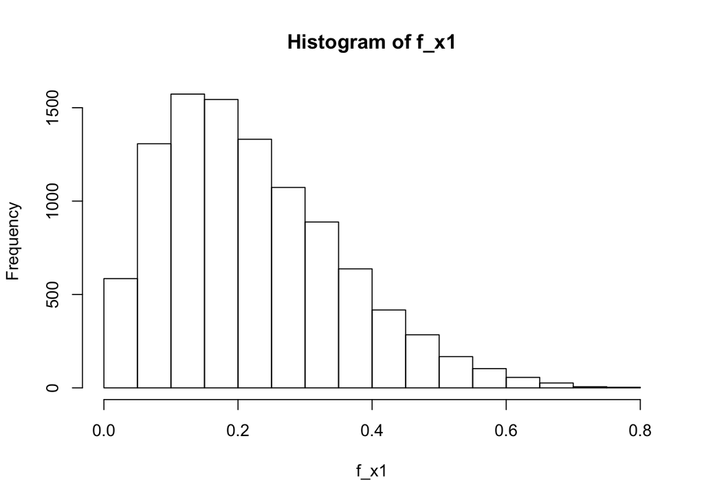

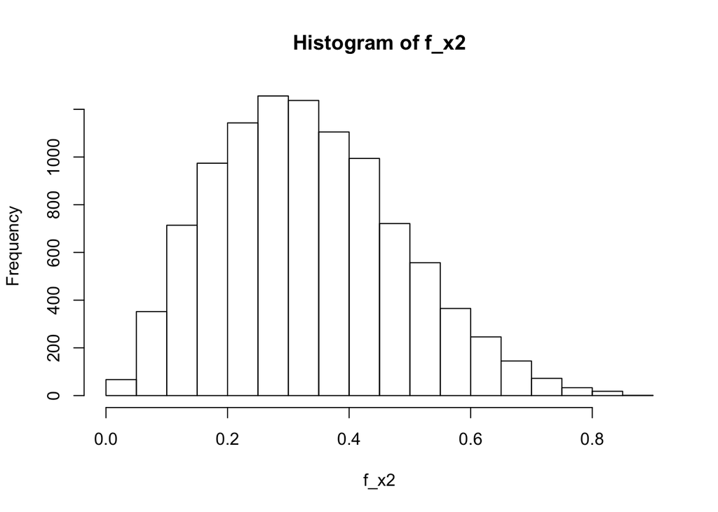

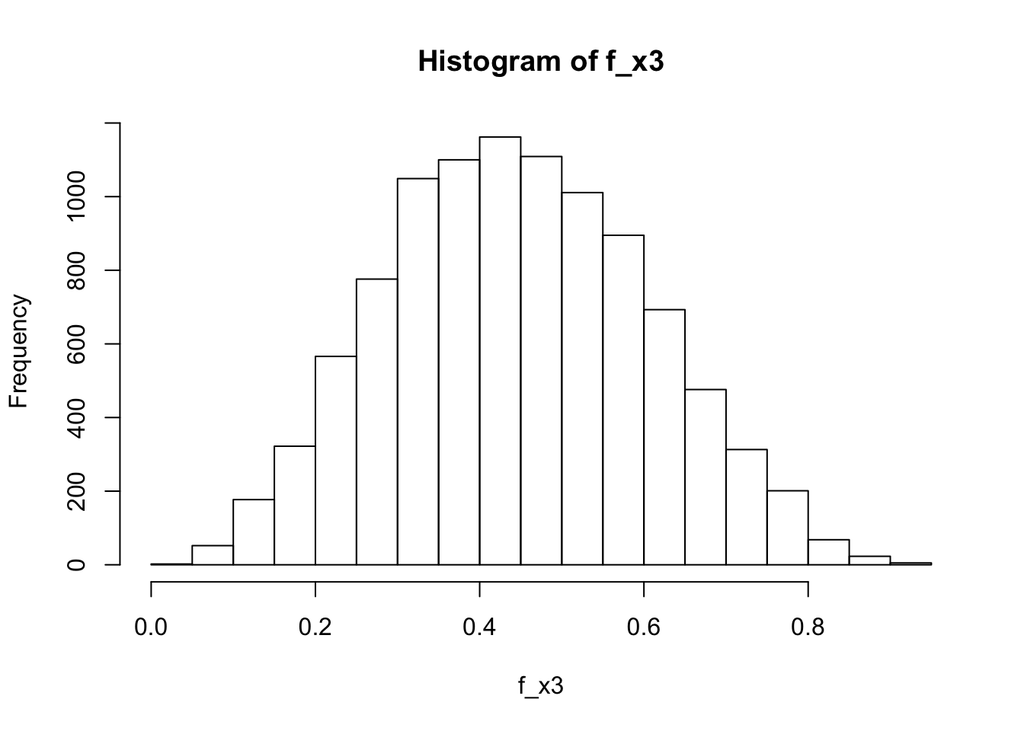

#### The Sample Mean

```
## The Sample Mean of x1 is :  0.2220068
```

```
## The Sample Mean of x2 is :  0.3319487
```

```
## The Sample Mean of x3 is :  0.4460445
```

#### The Covariance Matrix

```r
K <- cbind(f_x1,f_x2,f_x3)
cov(K)
```

```
##              f_x1         f_x2         f_x3
## f_x1  0.017455194 -0.007611647 -0.009843547
## f_x2 -0.007611647  0.022689865 -0.015078218
## f_x3 -0.009843547 -0.015078218  0.024921765
```

#### E[N] & Var[N]

```
## E[N]:  0.5564374
```

```
## Var[N]:  0.06940674
```

### 1(c)Algorithm of Sampling Dirichlet distribution through Gamma distribution

Step1: Generate $Y_i～\Gamma(\alpha_i , 1)$ where $i=1,2,...n$

Step2: Set $X_j = \frac{Y_j}{\sum_{k=1}^{n}Y_k}$ where $j=1,2,...,n$

#### Note

1. $\Gamma(\alpha_i , 1) = -\sum_{k=1}^{\alpha_i}\ln(U_k)$ where $U_k～Unif(0,1)$
2. $X_j$ has a $Dir(n,\alpha_1,...,\alpha_n)$ where $j=1,2,...,n$

### 1(d)

Sample $10^4$ data points.

```r
Y1<-rep(0,10000)
Y2<-rep(0,10000)
Y3<-rep(0,10000)
i<-1
repeat{
  y1<- -sum(log(runif(2,0,1)))
  Y1[i]<-y1
  y2<- -sum(log(runif(3,0,1)))
  Y2[i]<-y2
  y3<- -sum(log(runif(4,0,1)))
  Y3[i]<-y3
  i=i+1
  if(i == 10001){break}
}

M <- cbind(Y1,Y2,Y3)
dominator <- apply(M,1,sum)
X1<- Y1/dominator
X2<- Y2/dominator
X3<- Y3/dominator
```

#### The Histograms

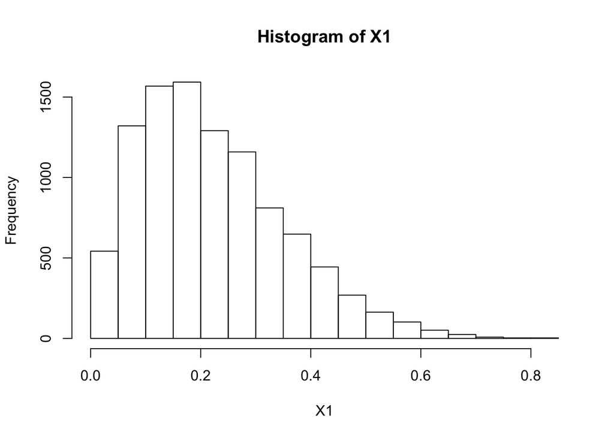

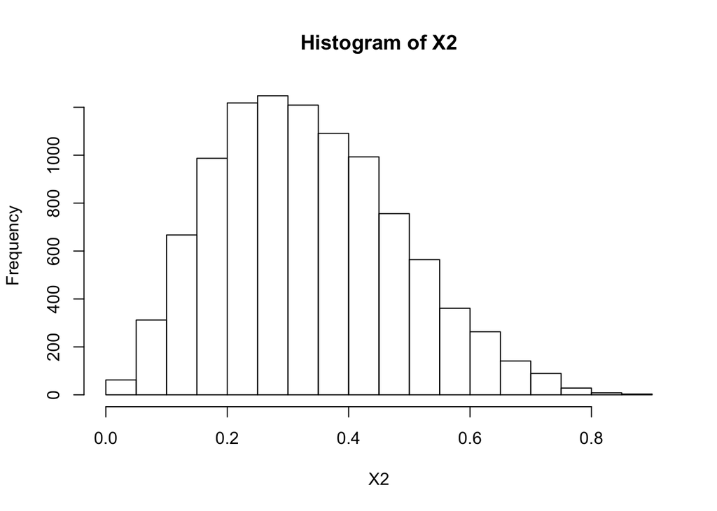

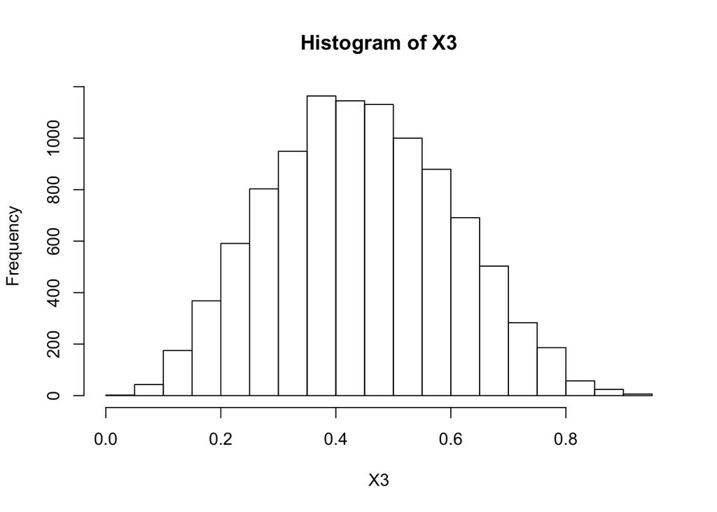

### Sample Mean

```
## The Sample Mean of x1 is :  0.2222028
```

```
## The Sample Mean of x2 is :  0.3339598
```

```
## The Sample Mean of x3 is :  0.4438374
```

### Covariance Matrix

```r
N <- cbind(X1,X2,X3)
cov(N)
```

```
##              X1           X2           X3
## X1  0.017276432 -0.007471036 -0.009805396
## X2 -0.007471036  0.022480654 -0.015009619
## X3 -0.009805396 -0.015009619  0.024815015
```

# Problem 2. Variance Reduction

We want to estimate the probability
$$P \lbrace A=\sum_{i=1}^{N} > 10\rbrace$$
$X_i ～ N(0,1) \ are \ i.i.d.$ and $N ～ Poisson(5)$ ； $X_i \perp N$

Sample $10^5$ data points.

### 2(a)Naive Monte Carlo

Step1: Generate $N ～ Poisson(5)$

Step3: Set $Y=1$ if $\sum_{i=1}^{N}X>10$

```r
j<-1
Y <- rep(0,100000)
N <- rpois(100000,5)
repeat{
  if(sum(rnorm(N[j],0,1)) > 10){
      Y[j] <- 1
  }
  j=j+1
  if(j==100001){
    break
  }
}
Probability <- sum(Y)/length(N)
Variance <- 100000*Probability*(1-Probability)
```

```
## The Sample Mean by Naive Monte Carlo is :  0.00005
```

```
## The Sample Variance by Naive Monte Carlo is :  4.99975
```

### 2(b)Using B=N As Control Variate

Step1: Generate $N ～ Poisson(5)$

Step2: Generate $X_i ～ Normal(0,1) \ i.i.d.$

Step3: Set $Y=1$ if $\sum_{i=1}^{N} > 10$

Step4: Set $C = \frac{-cov(Y,N)}{var(N)}$

#### Note

1. The Control Variate : $Var(Y+c(N-E[N]))$

```r
j<-1
Y <- rep(0,100000)
N <- rpois(100000,5)
repeat{
  if(sum(rnorm(N[j],0,1)) > 10){
    Y[j] <- 1
  }
  j=j+1
  if(j==100001){
    break
  }
}
c <- -cov(Y,N)/var(N)
C_V_reduction <- var(Y+c(N-mean(N)))
Mean <- mean(Y+c(N-mean(N)))
```

```
## The Sample Mean by Control Variate is :  0.00009
```

```
## The Sample Variance by Control Variate is :  4.985985
```

### 2(c)Variance Reduction Through Conditioning on N

Step1: Genetate $N ～ Poisson(5)$

Step2: Generate $X～ Normal(0,N)$

Step3: Set $Y=1, if\ X > 10$

```r
N <- rpois(100000,5)
K <- pnorm(10,0,sqrt(N),lower.tail = F)
Probability <- mean(K)
Variance <- var(K)
```

```
## The Sample Mean by Conditioning Variance Reduction is :  0.00007987126
```

```
## The Sample Variance by Conditioning Variance Reduction is :  0.00000006715415
```

### 2(d)Importance Sampling by N with Poisson(10)

Step1: Set the proposal $g_N ～ Poisson(10)$

Step2: Generate $N ～ Poisson(10)$

Step3: Set $X = \frac{P(\sum_{i=1}^{n}X_i | N=n) \times f_N(n)}{g_N(n)}$

#### Note

1. $f_N(n) ～ Poisson(5)$

```r
f_N <- function(x){
  return(exp(-5)*5^x/factorial(x))
}
g_N <- function(x){
  return(exp(-10)*10^x/factorial(x))
}
N <- rpois(100000,10)
X<-rep(0,100000)
for(i in 1:length(N)){
  X[i] <- pnorm(10,0,sqrt(N[i]),lower.tail = FALSE)*f_N(N[i])/g_N(N[i])
}
```

```
## The Sample Mean by Importance Sampling by N is :  0.00007916308
```

```
## The Sample Variance by Importance Sampling by N is :  0.00000000150374
```

### 2(e)Importance Sampling by Xi with Normal(2,1)

Step1: Generate $N ～ Poisson(5)$

Step2: Generate $X_1,...,X_N ～ Normal(2,1) \ i.i.d.$

Step3: Set$P(\sum_{i=1}^{N}X_i > 10)=\frac{1}{k}\sum_{j=1}^{k}I(\sum_{i=1}^{N}X_i > 10)\frac{f(X_1,X_2,...,X_N)}{g(Y_1,Y_2,...,Y_N)}$

#### Note

1. $f(X_i) ～ Normal(0,1)$
2. $g(X_i) ～ Normal(2,1)$

```r
f_g <- function(x){
  return(exp(-2*x+2))
}
X<-rep(0,100000)
N <- rpois(100000,5)
j<-1
repeat{
  Y <- rnorm(N[j],2,1)
  if(sum(Y)>10){
    X[j]<- prod(f_g(Y))
  }
  j<-j+1
  if(j==100001){
    break
  }
}
```

```
## The Sample Mean by Importance Sampling by Xi is :  0.00005885668
```

```
## The Sample Variance by Importance Sampling by Xi is :  0.000003958219
```

### 2(f)Importance Sampling by Xi with Normal(2,1) and N with Poisson(10)

Step1: Generate $N～Poisson(10)$

Step2: Generate $X_1,...,X_N ～Normal(2,1) \ i.i.d.$

Step3: Set$P(\sum_{i=1}^{N}X_i > 10)=\frac{1}{k}\sum_{j=1}^{k}I(\sum_{i=1}^{N}X_i > 10)\frac{f(X_1,X_2,...,X_N)}{g(Y_1,Y_2,...,Y_N)}\frac{h(n)}{l(n)}$

#### Note

1. $f(X_i) ～ Normal(0,1)$
2. $g(X_i) ～ Normal(2,1)$
3. $h(n) ～ Poisson(5)$
4. $l(n) ～ Poisson(10)$

```r
h_l <- function(n){
  return(exp(5)/2^n)
}
f_g <- function(x){
  return(exp(-2*x+2))
}
X<-rep(0,100000)
N <- rpois(100000,10)
j<-1
repeat{
  Y <- rnorm(N[j],2,1)
  if(sum(Y)>10){
    X[j]<- prod(f_g(Y))*h_l(N[j])
  }
  j<-j+1
  if(j==100001){
    break
  }
}
```

```
## The Sample Mean by Importance Sampling by Xi and N is :  0.00007166897
```

```
## The Sample Variance by Importance Sampling by Xi and N is :  0.00000339125
```

### 2(g)Prefered Sampling Method

The target $P \lbrace A=\sum_{i=1}^{N} > 10\rbrace$ is actuaaly a rare event. Thus, we need to sample a huge number of data points. However, by importance sampling, we can make the rare event become less rare, i.e. we do not need to sample such a huge number of sample points to do the estimation. Further, the bonus of importance sampling method is the variance reduction.

# Problem 3. Bootstrap and Jacknife

Use the 20 data points with $\hat{med}=0.3861$ to construct the confidence interval.

```
## The Sample Points :  0.0839 0.0205 0.3045 0.7816 0.0003 0.0095 0.4612 0.9996 0.9786 0.758 0.0002 0.731 0.0777 0.4483 0.4449 0.7943 0.1447 0.0431 0.8621 0.3273
```

### 3(a)Jacknife

#### Procedure

$$x_1,x_2,...x_{20}$$
are the given 20 data points.

Set
$$\hat{\theta_1}=\frac{x_2+...+x_{20}}{n-1}$$
$$\hat{\theta_2}=\frac{x_1+x_3+...+x_{20}}{n-1}$$
$$...$$
$$\hat{\theta_{20}}=\frac{x_1+...+x_{19}}{n-1}$$
$$n=20$$

Thus,
$$\hat{\theta_o} = \frac {\hat{\theta_1}+...+\hat{\theta_{20}}}{n}= \bar{x}$$
$$se^2 = \frac{n-1}{n}\sum_{i=1}^{n}(\hat{\theta_i}-\hat{\theta_o})^2$$

```r
Theta<-c()
for(i in 1:length(Sample)){
  theta <- sum(Sample[-i])/((length(Sample))-1)
  Theta<-c(Theta,theta)
}
se_square <- ((length(Theta)-1)^2/length(Theta))*var(Theta)
bias <- (length(Sample)-1)*(mean(Theta)-mean(Sample))
MSE <- se_square + bias
lower_bound <- median(Sample)-1.96*sqrt(se_square)
upper_bound <- median(Sample)+1.96*sqrt(se_square)
```

```
## [Jacksknife] 95%-confidence interval: [ 0.2278262 , 0.5443738 ]
```

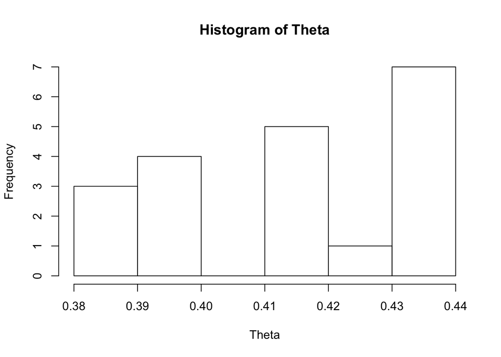

### 3(b)Bootstrap

In the given 20 data points, we resampling 20 points with replacement B times and get the $\hat{\theta^*_i}\ i=1,2,...,B$ .The $\hat{\theta^*_i}$ is the each mean of the resampling.

```r
B = 10000
bootstrap_data = numeric(B)
for(i in c(1:B)){
  bootstrap_data[i] = mean(sample(Sample,length(Sample),replace = TRUE))
}
se_B_square = var(bootstrap_data)
lower_bound <- median(Sample)-1.96*sqrt(se_B_square)
upper_bound <- median(Sample)+1.96*sqrt(se_B_square)
```

```
## [Bootstrap] 95%-confidence interval: [ 0.2300078 , 0.5421922 ]
```

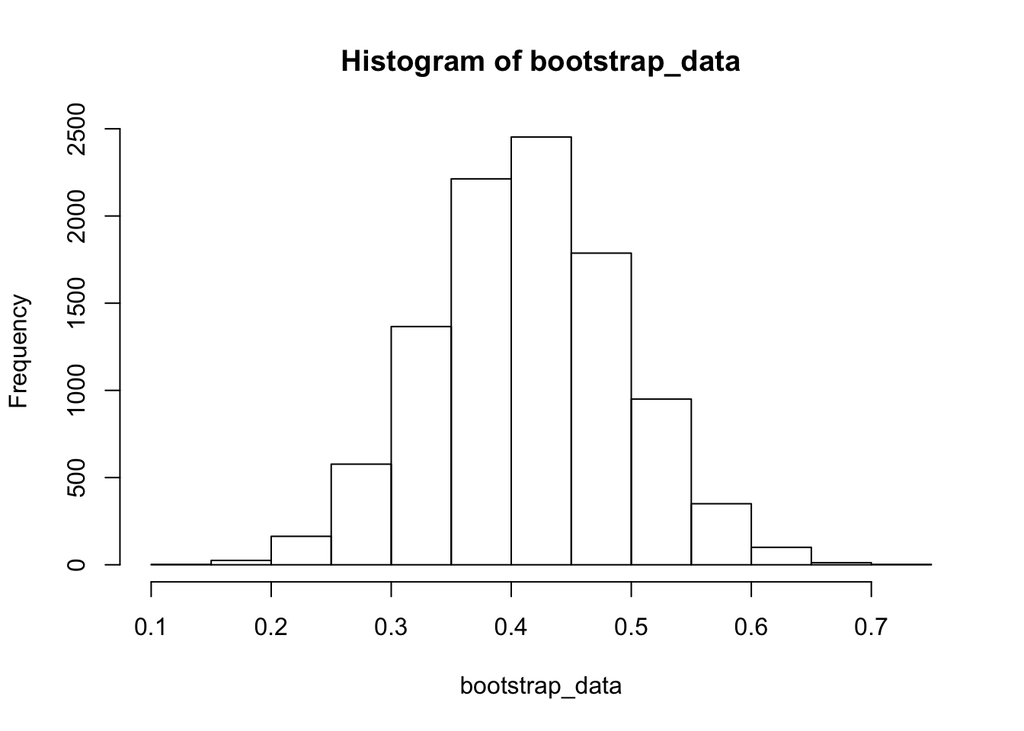

### 3(c)Parametric Bootstrap

In Beta Distribution, we know that $X～Beta(\alpha,\beta)$ has the expectation and variance with
$$E[X]=\frac{\alpha}{\alpha+\beta}$$
$$Var[X]= \frac{\alpha \beta}{(\alpha + \beta)^2(\alpha + \beta +1)}$$
Thus, we could estimate the raw value of $\alpha$ and $\beta$

```
## The Raw Value of Alpha is:  0.3555149
```

```
## The Raw Value of Beta is:  0.50412
```

Sampling $10^4$times from the raw estimate Beta Distribution as mentioned above.

Thus, we can get the new$10^4$ $\alpha$ and $\beta$.

```r
j<-1
N <- 10000
alpha <- rep(0,N)
beta <- rep(0,N)
repeat{
  K <- rbeta(10000,a,b)
  MM <- mean(K)
  VV <- var(K)
  al <- MM^2*(1-MM)/VV - MM
  be <- (1-MM)*al/MM
  alpha[j]<-al
  beta[j]<-be
  j <- j+1
  if(j==10001){
    break
  }
}
```

```r
MSE_Alpha_hat <- sum((alpha-a)^2)/N
MSE_Beta_hat <- sum((beta-b)^2)/N
lower_bound <- median(Sample)-1.96*sqrt(MSE_Alpha_hat)
upper_bound <- median(Sample)+1.96*sqrt(MSE_Beta_hat)
```

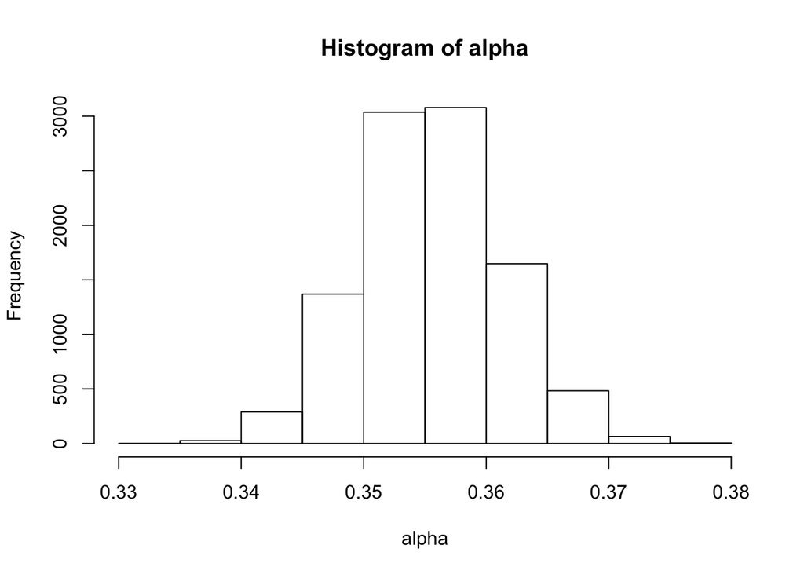

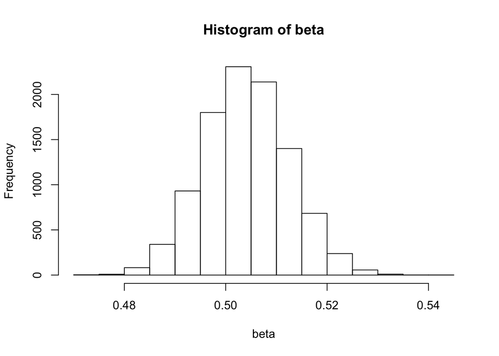

```
## [Parametric Bootstrap] 95%-confidence interval: [ 0.3747172 , 0.4024735 ]
```